# Project1-Background and Data

Mausham Bista

2023-09-19

In this project, we want to understand how an LED light bulb behaves over time, specially one that’s created with a seed value of 6943, as this was assigned to me. To do this, we are using a special library called ‘data4led’ that gives us data about LED bulbs.

```r
library(data4led)
```

```r
bulb <- led_bulb(1,seed = 6943)
# head(bulb)
```

To visually explore the LED bulbs percentage intensity over time, we create a scatter plot. This plot represent: * The x-axis in hours. * The y-axis as a percentage intensity.

We narrow the Y-axis range to focus on change in brightness by setting between 99% and 103%.

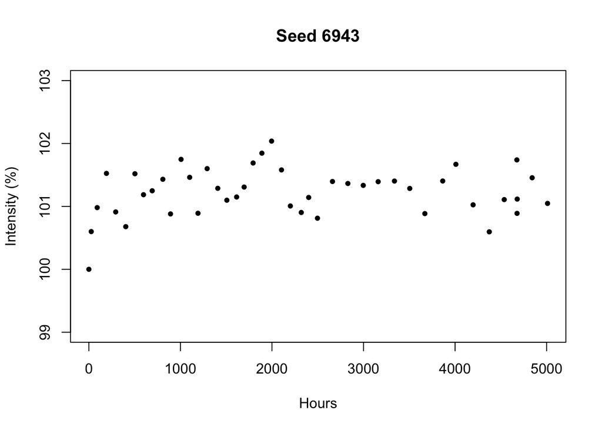

```r
x <- bulb$hours
y <- bulb$percent_intensity


plot(x, y, ylim=c(99, 103), pch= 20, main = 'Seed 6943', xlab='Hours', ylab = 'Intensity (%)' )
```

As per the plot, the first measurement was taken when time was 0 hours and last measurement was taken after 5000 hours.